# DHARMa: residual diagnostics for hierarchical (multi-level/mixed) regression models

# Notes on particular data types

## Poisson data

The main concern in Poisson data is dispersion. See comments in the section on the dispersion test, in particular regarding the advantage of conditional simulations in this case. To address overdispersion, I would recommend to prefer the negative binomial model over observation-level random effects, because this mode will be easier to test in DHARMa and its dispersion can be easier modeled, e.g. with glmmTMB. The third option would be quasi models, but there are few advantages, except runtime. Note also that quasi models cannot be tested with DHARMa.

Once dispersion is adjusted, you should check for heteroscedasticity (via standard plot, also against all predictors), and for zero-inflation. As noted, zero-inflation tests are often negative, and rather show up as underdispersion. Work through the owl example below.

## Proportional data

Proportional data expressed as percentage or fractions of a whole, i.e. non-count-based data, is often modeled with beta regressions. Those can be tested with DHARMa. Note that beta regressions are often 0 or 1 inflated. Both should be tested with testZeroInflation or testGeneric.

techniques for analysing continuous (also called non-count-based or non-binomial) proportions (e.g. percent cover, fraction time spent on an activity)

Note: discrete proportions, i.e. count-based proportions, of the type k/n should NOT be modeled with the beta regression. Use the binomial (see below).

## Binomial data

Binomial data behave slightly different depending on whether we have a 0/1 response (Bernoulli) or a k/n response (true binomial).

A k/n response, in particular when n is large, will behave similar to the Poisson, in that it approaches a normal distribution with fixed dispersion for large n and becomes more assymetric at its borders (for k = 0 or n). You should check for dispersion and consider a beta-binomial in cases of overdispersion.

Things are a bit different for the 0/1 response. Let’s look at the residuals of a clearly misspecified binomial model (missing predictor) with 0/1 response data.

```r
testData = createData(sampleSize = 500, overdispersion = 0, fixedEffects = 5,
                      family = binomial(), randomEffectVariance = 3,
                      numGroups = 25)

fittedModel <- glm(observedResponse ~ 1, family = "binomial", data = testData)

simulationOutput <- simulateResiduals(fittedModel = fittedModel)
```

If you would do the same with a binomial k/n response or count data, such a misspecification would produce overdispersion (try it out). For the 0/1 response we see neither dispersion problems nor a misfit in the general res ~ predicted plot.

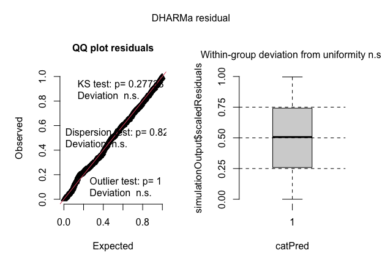

```r
plot(simulationOutput, asFactor = T)
```

Even though the misfit is clearly visible if we plot the residuals against the missing predictor.

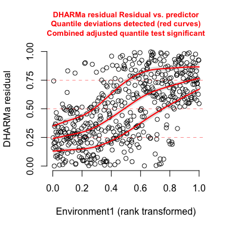

```r
plotResiduals(simulationOutput, testData$Environment1, quantreg = T)
```

However, we can see the overdispersion arising from the misfit if we group our residuals, which basically transforms the 0/1 response in a k/n response.

To show this, let’s look at the dispersion test for the same model, once ungrouped (left), and grouped according to the variable group which was in the data (right).

```r
par(mfrow = c(1,2))
testDispersion(simulationOutput)
```

```
##
##  DHARMa nonparametric dispersion test via sd of residuals fitted vs.
##  simulated
##
## data:  simulationOutput
## dispersion = 1.0023, p-value = 0.824
## alternative hypothesis: two.sided
```

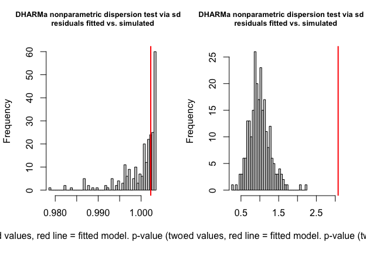

```
##
##  DHARMa nonparametric dispersion test via sd of residuals fitted vs.
##  simulated
##
## data:  simulationOutput
## dispersion = 3.0805, p-value < 2.2e-16
## alternative hypothesis: two.sided
```

```r
simulationOutput2 = recalculateResiduals(simulationOutput, group = testData$group)
testDispersion(simulationOutput2)
```

In general, you can group according to any variable that you like, including continous variables or space. However, some variables make more sense than others. To understand this, consider a simulation where we create binonial data with true probabilities p, drawn from a uniform distribution:

```r
n = 1000
p = runif(n, 0.1, 0.9) # true probabilities
obs = rbinom(n, 1, p)
```

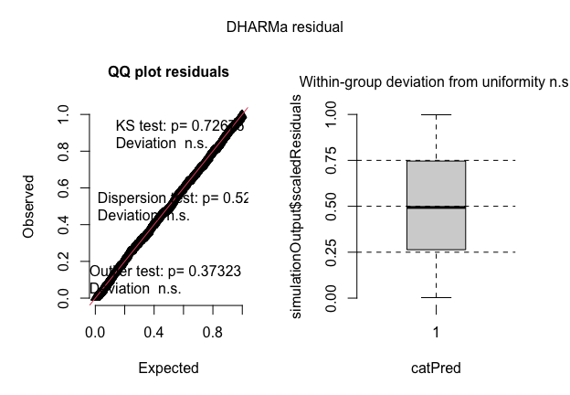

```r
fit <- glm(obs ~ 1, family = "binomial") # wrong model, assumes equal probabilities
library(DHARMa)
res <- simulateResiduals(fit, plot = T) # nothing to see
```

We see no misfit, and neither do we see a misfit when we group the data points randomly, as the mean of a random group is still fit well by the overall mean.

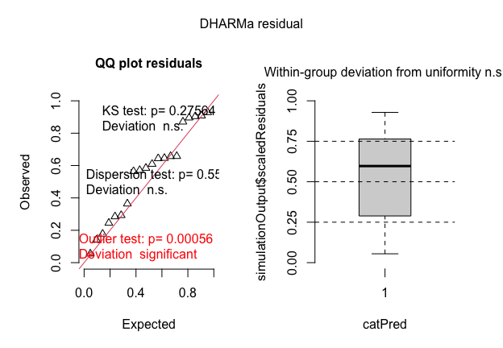

```r
res2 <- recalculateResiduals(res, group = rep(1:20, each = 10))
plot(res2)
```

However, we see thes misfit / overdispersion if we aggregate according to something that is correlated to the misfit. For our example, let’s just group according to the true means:

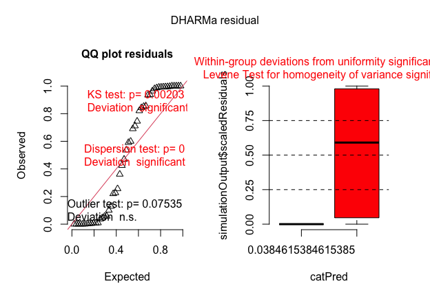

```r
grouping = cut(p, breaks = quantile(p, seq(0,1,0.02)))
res3 <- recalculateResiduals(res, group = grouping)
plot(res3)
```

In this case, the groups have a different mean than the fitted grand mean, and the misfit shows up in the residuals. Thus, what we are looking for in the grouping is variables that may correlate with the misfit.